# Hito3

[figure not shown]

## Predicción de datos en Educación Superior

## Motivación

La educación en nuestro país se ha transformado en un tema de debate, sobretodo en los últimos años, debido a la brecha que existe entre las metodologías de enseñanza impuestas por los colegios. Por otro lado, no todas las personas que terminan su etapa escolar logran entrar a la universidad, y quienes lo logran no necesariamente pueden egresar de su carrera debido a diversos factores. ¿Se puede en la realidad establecer una implicancia entre datos de la educación media y la universitaria de una persona?

Es interesante analizar cuáles son los agentes que podrían influir a la hora de terminar los estudios universitarios, pues las hipótesis no son pocas. Además, si se encuentra una relación directa con los atributos a estudiar, se podría llegar a predecir el tiempo de duración real de la carrera de una persona en específico.

## Hipótesis

Generalmente se habla del tipo de colegio y notas de enseñanza media como causas importantes del éxito o fracaso al ingresar a la educación superior. ¿Es esto cierto? ¿Realmente estas variables tienen una incidencia? ¿Existen otros atributos involucrados? La hipótesis inicial es que los datos sobre el colegio donde estudió una persona y su rendimiento (por ejemplo, comuna del colegio, NEM, tipo de colegio, nivel sí influyen a la hora de determinar cuánto se demorará realmente en terminar su carrera. Si la hipótesis es cierta, entonces, como se mencionó en la sección anterior, se pueden generar predicciones. La idea general es encontrar los atributos que puedan producir algún resultado respecto al período de estudios de cada persona.

## Descripción de los datos

Los datasets utilizados para estudiar todas las preguntas e hipótesis mencionadas anteriormente pertenecen al Ministerio de Educación. En particular, el primer y segundo dataset contienen los datos de todas las personas tituladas en 2015 y 2016: http://datos.mineduc.cl/dashboards/20207/descarga-bases-de-datos-titulados-de-educacion-superior/. Cada tabla está en formato csv y posee 42 columnas. Por otro lado, el tercer y cuarto dataset consisten en la información relativa a las notas de alumnos de enseñanza media entre los años 1990 y 2016 de jóvenes y adultos. Cada tabla tiene 8 columnas y también está en formato csv: http://datos.mineduc.cl/dashboards/20389/descarga-de-base-de-datos-notas-de-ensenanza-media-y-percentil-en-jovenes/.

## Hito 1

```python
import pandas as pd
import plotly
import numpy as np
import sys
import seaborn as sns; sns.set(color_codes=True)
from collections import defaultdict

import os
import glob
```

```python
input_dir = 'Titulados'
encoding = 'ISO-8859-1'
delimiter = ';'
decimal = '.'
```

```python
def filter_file(input_path):
    original = pd.read_csv(input_path, encoding='utf-8', sep=delimiter, decimal=decimal,dtype='unicode')
    filtered = original
    return filtered
```

```python
input_paths = glob.glob(os.path.join(input_dir, '*'))
filtered = None
output_path = None
dfs = []

for input_path in input_paths:
    print(input_path)
    dfs.append(filter_file(input_path))
    print ("listo")
```

```
Titulados/NEM_Y_PERCENTILES_JOVENES_2016_1990.csv
listo
Titulados/NEM_Y_PERCENTILES_ADULTOS_2016_1990.csv
listo
Titulados/Titulados_Educacion_Superior_2015.csv
listo
Titulados/Titulados_Educacion_Superior_2016.csv
listo
```

```python
dfs[0].head()
```

|  | RBD | COD_DEPE | AGNO_EGRESO | MRUN | NEM | PERCENTIL | PUESTO_10 | PUESTO_30 |
| --- | --- | --- | --- | --- | --- | --- | --- | --- |
| 0 | 2311 | 2 | 2015 | 196 | 4.90 | 50 | NO | NO |
| 1 | 22374 | 3 | 2013 | 276 | 5.13 | 70 | NO | NO |
| 2 | 22446 | 3 | 2013 | 277 | 6.55 | 10 | NO | SI |
| 3 | 5002 | 2 | 2016 | 332 | 6.65 | 10 | SI | SI |
| 4 | 25753 | 3 | 2007 | 337 | 4.93 | 50 | NO | NO |

```python
dfs[3].head()
```

|  | cat_periodo | codigo_unico | mrun | gen_alu | fec_nac_alu | edad_alu | rango_edad | año_ing_pri_año | sem_ing_pri_año | año_ing_carr | ... | ciudad_sede | jornada | modalidad | version | tipo_plan_carr | carac_plan_esp | area_cineunesco | oecd_area | oecd_subarea | area_carrera_generica_n |
| --- | --- | --- | --- | --- | --- | --- | --- | --- | --- | --- | --- | --- | --- | --- | --- | --- | --- | --- | --- | --- | --- |
| 0 | TIT_2016 | A2016_I100S10C10J1V1 | 3246683 | 1 | 199301 | 23 | 20 A 24 AÑOS | 2013 | 1 |  | ... | PUNTA ARENAS | DIURNO | PRESENCIAL | 1 | PLAN REGULAR | NO APLICA | TECNOLOGÍA | SERVICIOS | SERVICIOS DE SEGURIDAD | INGENIERÍA EN PREVENCIÓN DE RIESGOS |
| 1 | TIT_2016 | A2016_I100S10C10J1V1 | 3752168 | 1 | 198912 | 27 | 25 A 29 AÑOS | 9998 |  | 2014 | ... | PUNTA ARENAS | DIURNO | PRESENCIAL | 1 | PLAN REGULAR | NO APLICA | TECNOLOGÍA | SERVICIOS | SERVICIOS DE SEGURIDAD | INGENIERÍA EN PREVENCIÓN DE RIESGOS |
| 2 | TIT_2016 | A2016_I100S10C10J1V1 | 4867037 | 1 | 199405 | 22 | 20 A 24 AÑOS | 2012 | 1 |  | ... | PUNTA ARENAS | DIURNO | PRESENCIAL | 1 | PLAN REGULAR | NO APLICA | TECNOLOGÍA | SERVICIOS | SERVICIOS DE SEGURIDAD | INGENIERÍA EN PREVENCIÓN DE RIESGOS |
| 3 | TIT_2016 | A2016_I100S10C10J1V1 | 5197286 | 1 | 199307 | 23 | 20 A 24 AÑOS | 9998 |  | 2014 | ... | PUNTA ARENAS | DIURNO | PRESENCIAL | 1 | PLAN REGULAR | NO APLICA | TECNOLOGÍA | SERVICIOS | SERVICIOS DE SEGURIDAD | INGENIERÍA EN PREVENCIÓN DE RIESGOS |
| 4 | TIT_2016 | A2016_I100S10C10J1V1 | 5844136 | 1 | 199303 | 23 | 20 A 24 AÑOS | 2012 | 1 |  | ... | PUNTA ARENAS | DIURNO | PRESENCIAL | 1 | PLAN REGULAR | NO APLICA | TECNOLOGÍA | SERVICIOS | SERVICIOS DE SEGURIDAD | INGENIERÍA EN PREVENCIÓN DE RIESGOS |

5 rows × 42 columns

Dado que ambas tablas tienen como llave MRUN del alumno, se puede generar sólo una a partir del cruce de datos, y así poder agregar más atributos a la tabla de titulados. A continuación se muestra lo anteriormente descrito:

```python
#Cambiar a minusculas las columnas para poder hacer merge

dfs[0].columns = [x.lower() for x in dfs[0].columns]
dfs[1].columns=[x.lower() for x in dfs[1].columns]
dfs[2]['cat_periodo']=2015
dfs[3]['cat_periodo']=2016
```

```python
#Concatenar las tablas de titulados
frames=[dfs[2],dfs[3]]
titulados2=pd.concat(frames,ignore_index=True)
```

```python
frames2=[dfs[0],dfs[1]]
egresados=pd.concat(frames2,ignore_index=True)
```

```python
# merge de tabla de egresados y titulados que va a mostrar la intersección por mrun
total=pd.merge(egresados,titulados2, on='mrun', how='inner')
```

```python
total.head()
```

|  | rbd | cod_depe | agno_egreso | mrun | nem | percentil | puesto_10 | puesto_30 | cat_periodo | codigo_unico | ... | ciudad_sede | jornada | modalidad | version | tipo_plan_carr | carac_plan_esp | area_cineunesco | oecd_area | oecd_subarea | area_carrera_generica_n |
| --- | --- | --- | --- | --- | --- | --- | --- | --- | --- | --- | --- | --- | --- | --- | --- | --- | --- | --- | --- | --- | --- |
| 0 | 10452 | 1 | 2009 | 5 | 4.93 | 90 | NO | NO | 2016 | A2016_I260S47C118J1V1 | ... | SANTIAGO | DIURNO | PRESENCIAL | 1 | PLAN REGULAR | NO APLICA | SALUD | SALUD Y SERVICIOS SOCIALES | MEDICINA | TÉCNICO EN ENFERMERÍA |
| 1 | 3247 | 2 | 2009 | 410 | 5.38 | 70 | NO | NO | 2015 | A2015_I31S2C46J1V1 | ... | TALCA | DIURNO | PRESENCIAL |  | PLAN REGULAR | NO APLICA | SALUD | SALUD Y SERVICIOS SOCIALES | MEDICINA | FONOAUDIOLOGÍA |
| 2 | 8514 | 2 | 2013 | 443 | 5.15 | 90 | NO | NO | 2016 | A2016_I143S7C59J1V1 | ... | SANTIAGO | DIURNO | PRESENCIAL | 1 | PLAN REGULAR | NO APLICA | ARTE Y ARQUITECTURA | SERVICIOS | SERVICIOS PERSONALES | TÉCNICO EN PELUQUERÍA Y ESTÉTICA |
| 3 | 648 | 3 | 2007 | 481 | 5.53 | 60 | NO | NO | 2016 | A2016_I430S27C138J1V1 | ... | LA SERENA | DIURNO | PRESENCIAL | 1 | PLAN REGULAR | NO APLICA | TECNOLOGÍA | SERVICIOS | SERVICIOS DE SEGURIDAD | TÉCNICO EN PREVENCIÓN DE RIESGOS |
| 4 | 2455 | 3 | 2005 | 542 | 6.38 | 10 | NO | SI | 2016 | A2016_I70S1C178J1V1 | ... | SANTIAGO | DIURNO | PRESENCIAL | 1 | PLAN REGULAR | NO APLICA | CIENCIAS SOCIALES | CIENCIAS SOCIALES, ENSEÑANZA COMERCIAL Y DERECHO | CIENCIAS SOCIALES Y DEL COMPORTAMIENTO | SOCIOLOGÍA |

5 rows × 49 columns

Por lo que el tamaño de nuestro Data set queda:

```python
total.shape
```

```
(293997, 49)
```

## Exploración de datos

### Limpieza de datos

A continuación será necesario revisar si existen anomalías en los datos:

#### Duplicados

```python
mrundup = total.mrun.value_counts()
mrundup[mrundup > 1].head()
```

```
2664582     4
17740265    4
19994535    4
24280384    4
12970556    4
Name: mrun, dtype: int64
```

A continuación revisamos en detalle algunos mrun repetidos:

```python
total.loc[total['mrun']=='1712224']
```

|  | rbd | cod_depe | agno_egreso | mrun | nem | percentil | puesto_10 | puesto_30 | cat_periodo | codigo_unico | ... | ciudad_sede | jornada | modalidad | version | tipo_plan_carr | carac_plan_esp | area_cineunesco | oecd_area | oecd_subarea | area_carrera_generica_n |
| --- | --- | --- | --- | --- | --- | --- | --- | --- | --- | --- | --- | --- | --- | --- | --- | --- | --- | --- | --- | --- | --- |
| 18807 | 6112 | 3 | 2009 | 1712224 | 6.50 | 10 | NO | SI | 2015 | A2015_T_94_P_2 | ... | TEMUCO | DIURNO | PRESENCIAL |  | PLAN REGULAR | NO APLICA | SALUD | SALUD Y SERVICIOS SOCIALES | MEDICINA | POSTÍTULO EN SALUD |
| 18808 | 6112 | 3 | 2009 | 1712224 | 6.50 | 10 | NO | SI | 2015 | A2016_T_94_P_21 | ... | TEMUCO | DIURNO | PRESENCIAL |  | PLAN REGULAR | NO APLICA | SALUD | SALUD Y SERVICIOS SOCIALES | MEDICINA | POSTÍTULO EN SALUD |
| 18809 | 6112 | 3 | 2009 | 1712224 | 6.50 | 10 | NO | SI | 2016 | A2016_T_94_P_11 | ... | TEMUCO | A DISTANCIA | NO PRESENCIAL |  | PLAN REGULAR | NO APLICA | SALUD | SALUD Y SERVICIOS SOCIALES | MEDICINA | POSTÍTULO EN SALUD |
| 18810 | 6112 | 3 | 2009 | 1712224 | 6.50 | 10 | NO | SI | 2016 | A2016_T_94_P_2 | ... | TEMUCO | DIURNO | PRESENCIAL |  | PLAN REGULAR | NO APLICA | SALUD | SALUD Y SERVICIOS SOCIALES | MEDICINA | POSTÍTULO EN SALUD |

4 rows × 49 columns

```python
total.loc[total['mrun']=='2622180']
```

|  | rbd | cod_depe | agno_egreso | mrun | nem | percentil | puesto_10 | puesto_30 | cat_periodo | codigo_unico | ... | ciudad_sede | jornada | modalidad | version | tipo_plan_carr | carac_plan_esp | area_cineunesco | oecd_area | oecd_subarea | area_carrera_generica_n |
| --- | --- | --- | --- | --- | --- | --- | --- | --- | --- | --- | --- | --- | --- | --- | --- | --- | --- | --- | --- | --- | --- |
| 28887 | 5467 | 3 | 2010 | 2622180 | 6.25 | 10 | NO | SI | 2015 | A2015_T_94_P_28 | ... | TEMUCO | DIURNO | PRESENCIAL |  | PLAN REGULAR | NO APLICA | HUMANIDADES | HUMANIDADES Y ARTES | HUMANIDADES | POSTÍTULO EN HUMANIDADES |
| 28888 | 5467 | 3 | 2010 | 2622180 | 6.25 | 10 | NO | SI | 2016 | A2016_T_94_P_33 | ... | TEMUCO | DIURNO | PRESENCIAL |  | PLAN REGULAR | NO APLICA | AGROPECUARIA | AGRICULTURA | VETERINARIA | POSTÍTULO EN AGROPECUARIA |

2 rows × 49 columns

De lo anterior se puede deducir que existen algunos mrun que estan repetidos innecesariamente mienstras otros son porque el alumno estudió más de una carrera o hizo un postgrado. Ahora dado que la mayoría de los repetidos son postítulos, la alternativa más sencilla es eliminar las filas que tienen postítulos, ya que esto no es relevante en el análisis (sólo se quiere estudiar la gente que obtuvo un grado académio):

```python
# filtrar todos los que  no seas postitulo
total=total.loc[total['nivel_global']!=u'POSTÍTULO']
```

#### Datos erróneos

De acuerdo a nuestra hipótesis se quiere medir los años reales que al alumno le tomó titularse, por lo que se quiere ver si existe incongruencia en la diferencia de año de ingreso a la universidad y año de titulación.

```python
total[[u'año_ing_pri_año']] = total[[u'año_ing_pri_año']].astype(int)
```

```python
columns=['cat_periodo',u'año_ing_pri_año']
```

```python
total=total.loc[total['cat_periodo']-total[u'año_ing_pri_año']>0]
```

#### Columnas Faltantes

Ahora que no se tiene incongruencia entre los años de titulación e ingreso a la carrera se creará la columna años_carrera para que para cada alumno se tenga los años que demoró en obtener el título y la columna duración total en años, pues la actual se encuentra en semestres:

```python
total['anos_carrera']=total['cat_periodo']-total[u'año_ing_pri_año']
```

```python
total.head()
```

|  | rbd | cod_depe | agno_egreso | mrun | nem | percentil | puesto_10 | puesto_30 | cat_periodo | codigo_unico | ... | jornada | modalidad | version | tipo_plan_carr | carac_plan_esp | area_cineunesco | oecd_area | oecd_subarea | area_carrera_generica_n | anos_carrera |
| --- | --- | --- | --- | --- | --- | --- | --- | --- | --- | --- | --- | --- | --- | --- | --- | --- | --- | --- | --- | --- | --- |
| 0 | 10452 | 1 | 2009 | 5 | 4.93 | 90 | NO | NO | 2016 | A2016_I260S47C118J1V1 | ... | DIURNO | PRESENCIAL | 1 | PLAN REGULAR | NO APLICA | SALUD | SALUD Y SERVICIOS SOCIALES | MEDICINA | TÉCNICO EN ENFERMERÍA | 6 |
| 1 | 3247 | 2 | 2009 | 410 | 5.38 | 70 | NO | NO | 2015 | A2015_I31S2C46J1V1 | ... | DIURNO | PRESENCIAL |  | PLAN REGULAR | NO APLICA | SALUD | SALUD Y SERVICIOS SOCIALES | MEDICINA | FONOAUDIOLOGÍA | 4 |
| 2 | 8514 | 2 | 2013 | 443 | 5.15 | 90 | NO | NO | 2016 | A2016_I143S7C59J1V1 | ... | DIURNO | PRESENCIAL | 1 | PLAN REGULAR | NO APLICA | ARTE Y ARQUITECTURA | SERVICIOS | SERVICIOS PERSONALES | TÉCNICO EN PELUQUERÍA Y ESTÉTICA | 2 |
| 4 | 2455 | 3 | 2005 | 542 | 6.38 | 10 | NO | SI | 2016 | A2016_I70S1C178J1V1 | ... | DIURNO | PRESENCIAL | 1 | PLAN REGULAR | NO APLICA | CIENCIAS SOCIALES | CIENCIAS SOCIALES, ENSEÑANZA COMERCIAL Y DERECHO | CIENCIAS SOCIALES Y DEL COMPORTAMIENTO | SOCIOLOGÍA | 9 |
| 5 | 9347 | 3 | 2009 | 571 | 5.65 | 20 | NO | SI | 2015 | A2016_I17S2C41J2V1 | ... | VESPERTINO | PRESENCIAL | 1 | PLAN REGULAR | NO APLICA | EDUCACIÓN | EDUCACIÓN | FORMACIÓN DE PERSONAL DOCENTE | PEDAGOGÍA EN EDUCACIÓN DE PÁRVULOS | 4 |

5 rows × 50 columns

```python
total[['dur_total_carr']] = total[['dur_total_carr']].astype(int)
```

```python
total['dur_total_anos']=total['dur_total_carr']/int(2)
```

```python
total.head()
```

|  | rbd | cod_depe | agno_egreso | mrun | nem | percentil | puesto_10 | puesto_30 | cat_periodo | codigo_unico | ... | modalidad | version | tipo_plan_carr | carac_plan_esp | area_cineunesco | oecd_area | oecd_subarea | area_carrera_generica_n | anos_carrera | dur_total_anos |
| --- | --- | --- | --- | --- | --- | --- | --- | --- | --- | --- | --- | --- | --- | --- | --- | --- | --- | --- | --- | --- | --- |
| 0 | 10452 | 1 | 2009 | 5 | 4.93 | 90 | NO | NO | 2016 | A2016_I260S47C118J1V1 | ... | PRESENCIAL | 1 | PLAN REGULAR | NO APLICA | SALUD | SALUD Y SERVICIOS SOCIALES | MEDICINA | TÉCNICO EN ENFERMERÍA | 6 | 2.5 |
| 1 | 3247 | 2 | 2009 | 410 | 5.38 | 70 | NO | NO | 2015 | A2015_I31S2C46J1V1 | ... | PRESENCIAL |  | PLAN REGULAR | NO APLICA | SALUD | SALUD Y SERVICIOS SOCIALES | MEDICINA | FONOAUDIOLOGÍA | 4 | 5.5 |
| 2 | 8514 | 2 | 2013 | 443 | 5.15 | 90 | NO | NO | 2016 | A2016_I143S7C59J1V1 | ... | PRESENCIAL | 1 | PLAN REGULAR | NO APLICA | ARTE Y ARQUITECTURA | SERVICIOS | SERVICIOS PERSONALES | TÉCNICO EN PELUQUERÍA Y ESTÉTICA | 2 | 2.5 |
| 4 | 2455 | 3 | 2005 | 542 | 6.38 | 10 | NO | SI | 2016 | A2016_I70S1C178J1V1 | ... | PRESENCIAL | 1 | PLAN REGULAR | NO APLICA | CIENCIAS SOCIALES | CIENCIAS SOCIALES, ENSEÑANZA COMERCIAL Y DERECHO | CIENCIAS SOCIALES Y DEL COMPORTAMIENTO | SOCIOLOGÍA | 9 | 5.0 |
| 5 | 9347 | 3 | 2009 | 571 | 5.65 | 20 | NO | SI | 2015 | A2016_I17S2C41J2V1 | ... | PRESENCIAL | 1 | PLAN REGULAR | NO APLICA | EDUCACIÓN | EDUCACIÓN | FORMACIÓN DE PERSONAL DOCENTE | PEDAGOGÍA EN EDUCACIÓN DE PÁRVULOS | 4 | 5.0 |

5 rows × 51 columns

#### Eliminación de columnas

Si bien hay muchos atributos que son relevantes para este estudio, la dimensión de la tabla resultante no es pequeña, por lo que es probable que no todos los atributos sean imprescindibles. Así, las columnas que se pueden eliminar son las siguientes:

- fec_nac_alu: La fecha de nacimiento del alumno no es relevante salvo para determinar la edad, pero la edad ya está contenida en una columna aparte (edad_alu).
- año_ing_carr: Para efectos del proyecto, sólo se considerará año de ingreso a primer año (año_ing_pri_año).
- sem_ing_carr: Para efectos del proyecto, no se considerará semestre de ingreso.
- sem_ing_pri_año: No se considerará semestre de ingreso, además de poseer muchos filas con valores sin información.
- fecha_obtencion_titulo: Similar a lo que ocurre con la fecha de nacimiento del alumno (sólo importa el año, cuyo valor ya está en otra columna).
- version: Posee muy pocos valores no nulos.
- carac_plan_esp: No entrega información relevante. Posee muchos valores nulos o sin información.

### Visualización de Datos

A continuación se presentarán gráficos para ver relaciones entre los datos, outliers, etc. Primero se reemplazarán los valores null por 0 para poder graficar:

```python
total=total.fillna(0)
total[['edad_alu', 'dur_estudio_carr']] = total[['edad_alu', 'dur_estudio_carr']].astype(int)
total[['nem']] = total[['nem']].astype(float)
```

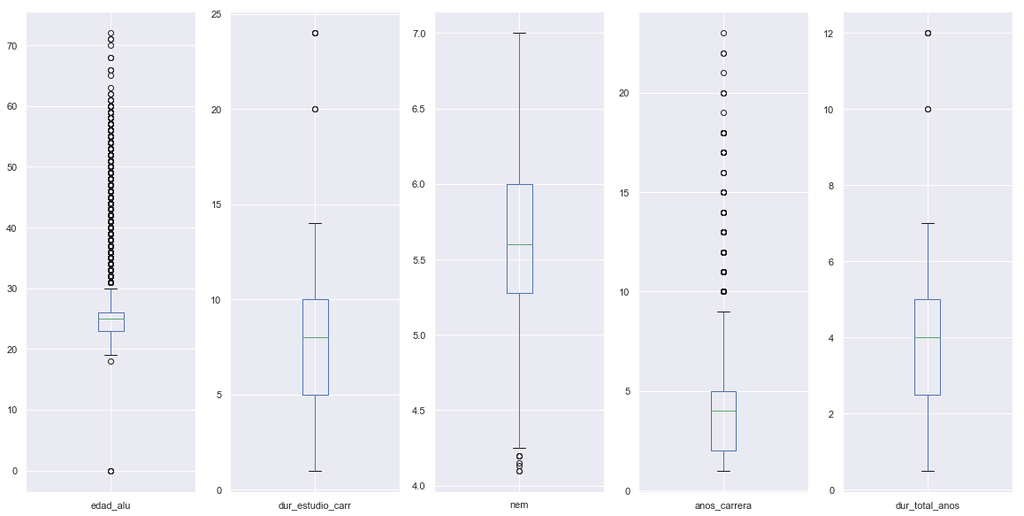

```python
import matplotlib.pyplot as plt
import pandas

names = ['edad_alu', 'dur_estudio_carr','nem','anos_carrera','dur_total_anos']
filtrado=total.filter(items=names)
filtrado.plot(kind='box', subplots=True, sharex=False, sharey=False,figsize=(20,10))
plt.show()
```

En la figura anterior (box plot), se muestra que en la edad de los alumnos hay valores extremos como alumnos que tienen edades mayores a 50 y edad 0 ( la cual es falta de información)

A continuación separaremos los datos por código de dependencia del colegio y se compararán con respecto al nem

```python
municipales=total.loc[(total['cod_depe']=='1') | (total['cod_depe']=='2')]
particulares=total.loc[total['cod_depe']=='4']
subvencionados=total.loc[(total['cod_depe']=='3')| (total['cod_depe']=='5')]
```

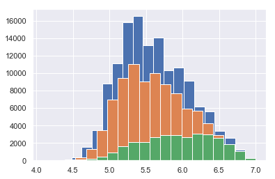

```python
subvencionados['nem'].hist(bins=20)
municipales['nem'].hist(bins=20)
particulares['nem'].hist(bins=20)
```

En el gráfico anterior se ve que los colegios subvencionados y municipales tienen similar nem. Por otro lado, los colegios privados tienen mejor nem que los subvencionados y municipales (entre 60-65).

Luego, se quiere analizar el total de matriculados por género y dependencia:

```python
municipalesHombre=municipales.loc[municipales['gen_alu']=='1']
subvencionadosHombre=subvencionados.loc[subvencionados['gen_alu']=='1']
particularesHombre=particulares.loc[particulares['gen_alu']=='1']
```

```python
municipalesMujer=municipales.loc[municipales['gen_alu']=='2']
subvencionadosMujer=subvencionados.loc[subvencionados['gen_alu']=='2']
particularesMujer=particulares.loc[particulares['gen_alu']=='2']
```

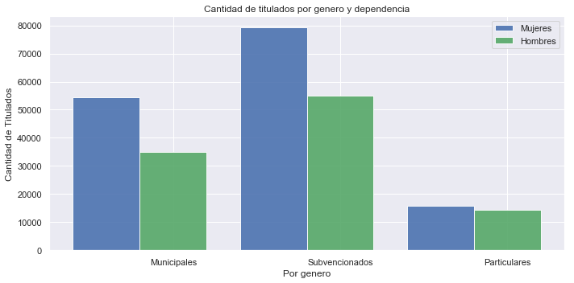

```python
listaHombres=[34844,55098,14448]
listaMujeres=[54465,79231,15824]
# -*- coding: utf-8 -*-
import numpy as np
import matplotlib.pyplot as plt

# data to plot
n_groups = 3
means_franka = tuple(listaMujeres)
means_guidoa = tuple(listaHombres)

# create plot
fig, ax = plt.subplots(figsize=(10, 5))
index = np.arange(n_groups)
bar_width = 0.40
opacity = 0.9

rects1 = plt.bar(index, means_franka, bar_width,
                 alpha=opacity,
                 color='b',
                 label=u'Mujeres')

rects2 = plt.bar(index + bar_width, means_guidoa, bar_width,
                 alpha=opacity,
                 color='g',
                 label=u'Hombres')

plt.xlabel(u'Por genero')
plt.ylabel(u'Cantidad de Titulados')
plt.title(u'Cantidad de titulados por genero y dependencia')
plt.xticks(index + bar_width, (u'Municipales',u'Subvencionados',u'Particulares'))
plt.legend()


plt.tight_layout()
plt.show()
```

Del gráfico se deduce que el número de titulados de colegios subvencionados es significativamente mayor a las otras dependencias y el número de alumnos mujeres es mayor en todas las dependencias.

Dado esto, se decidió comparar porcentajes y comparar por tipo de institución:

```python
centroFormacionTecnica=total.loc[total[u'tipo_inst_2']==u'CENTROS DE FORMACI\xd3N T\xc9CNICA']
universidadprivada=total.loc[total[u'tipo_inst_2']=='UNIVERSIDADES PRIVADAS']
institutoprofesional=total.loc[total[u'tipo_inst_2']=='INSTITUTOS PROFESIONALES']
universidadtradicional=total.loc[total[u'tipo_inst_2']=='UNIVERSIDADES CRUCH']

centroFormacionTecnicamunicipales=centroFormacionTecnica.loc[(centroFormacionTecnica['cod_depe']=='1') | (centroFormacionTecnica['cod_depe']=='2')]
centroFormacionTecnicasubvencionados=centroFormacionTecnica.loc[(centroFormacionTecnica['cod_depe']=='3') | (centroFormacionTecnica['cod_depe']=='5')]
centroFormacionTecnicaparticulares=centroFormacionTecnica.loc[centroFormacionTecnica['cod_depe']=='4']

universidadprivadamunicipales=universidadprivada.loc[(universidadprivada['cod_depe']=='1') | (universidadprivada['cod_depe']=='2')]
universidadprivadasubvencionados=universidadprivada.loc[(universidadprivada['cod_depe']=='3') | (universidadprivada['cod_depe']=='5')]
universidadprivadaprivados=universidadprivada.loc[universidadprivada['cod_depe']=='4']

institutoprofesionalmunicipales=institutoprofesional.loc[(institutoprofesional['cod_depe']=='1') | (institutoprofesional['cod_depe']=='2')]
institutoprofesionalsubvencionados=institutoprofesional.loc[(institutoprofesional['cod_depe']=='3') | (institutoprofesional['cod_depe']=='5')]
institutoprofesionalprivados=institutoprofesional.loc[institutoprofesional['cod_depe']=='4']

universidadtradicionalmunicipales=universidadtradicional.loc[(universidadtradicional['cod_depe']=='1') | (universidadtradicional['cod_depe']=='2')]
universidadtradicionalsubvencionados=universidadtradicional.loc[(universidadtradicional['cod_depe']=='3') | (universidadtradicional['cod_depe']=='5')]
universidadtradicionalprivados=universidadtradicional.loc[universidadtradicional['cod_depe']=='4']
```

```python
listamunicipales2=[(35379/float(86771))*100,(19081/float(42517))*100,(16198/float(66430))*100,(18651/float(58209))*100]
```

```python
listasubvencionados=[(48968/float(86771))*100,(22524/float(42517))*100,(33956/float(66430))*100,(28881/float(58209))*100]
```

```python
listaprivados2=[(2416/float(86771))*100,(908/float(42517))*100,(16273/float(66430))*100,(10675/float(58209))*100]
```

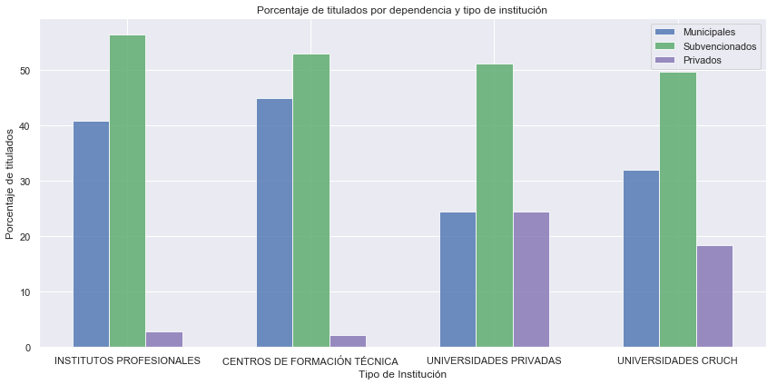

```python
# -*- coding: utf-8 -*-
import numpy as np
import matplotlib.pyplot as plt

# data to plot
n_groups = 4
means_franka = tuple(listamunicipales2)
means_guidoa = tuple(listasubvencionados)
privados= tuple(listaprivados2)

# create plot
fig, ax = plt.subplots(figsize=(12, 6))
index = np.arange(n_groups)
bar_width = 0.20
opacity = 0.8

rects1 = plt.bar(index, means_franka, bar_width,
                 alpha=opacity,
                 color='b',
                 label=u'Municipales')

rects2 = plt.bar(index + bar_width, means_guidoa, bar_width,
                 alpha=opacity,
                 color='g',
                 label=u'Subvencionados')

rects3 =  plt.bar(index + 2*bar_width, privados, bar_width,
                 alpha=opacity,
                 color='m',
                 label=u'Privados')

plt.xlabel(u'Tipo de Institución')
plt.ylabel(u'Porcentaje de titulados')
plt.title(u'Porcentaje de titulados por dependencia y tipo de institución')
plt.xticks(index + bar_width, (u'INSTITUTOS PROFESIONALES',u'CENTROS DE FORMACI\xd3N T\xc9CNICA',u'UNIVERSIDADES PRIVADAS',u'UNIVERSIDADES CRUCH'))
plt.legend()

plt.tight_layout()
plt.savefig('prueba')
plt.show()
```

Finalmente se realizó un parallel coordinates para ver las relaciones entre los atributos de la siguiente forma:

```python
mydict={u'INSTITUTOS PROFESIONALES':1,
         u'UNIVERSIDADES PRIVADAS':2,
         u'CENTROS DE FORMACI\xd3N T\xc9CNICA':3,
          u'UNIVERSIDADES CRUCH':4
}
```

```python
ans=[]
for key,value in mydict.items():
        ans.append([key,value])
```

```python
tipoInst=pd.DataFrame(ans, columns=['tipo_inst_2','cod_tipo_inst'])
```

```python
total1=pd.merge(total,tipoInst,on='tipo_inst_2',how='inner')
```

```python
total2=pd.DataFrame(total1, columns=['tipo_inst_2','cod_tipo_inst'])
```

```python
import colorlover as cl
import plotly.plotly as py
import plotly.graph_objs as go
from plotly.offline import download_plotlyjs, init_notebook_mode, plot, iplot

def configure_plotly_browser_state():
    import IPython
    display(IPython.core.display.HTML('''
        <script src="/static/components/requirejs/require.js"></script>
        <script>
          requirejs.config({
            paths: {
              base: '/static/base',
              plotly: 'https://cdn.plot.ly/plotly-latest.min.js?noext',
            },
          });
        </script>
        '''))
init_notebook_mode(connected=False)
```

```python
colorscale = [[i,x] for i,x in enumerate(cl.scales['5']['div']['RdYlBu'])]
configure_plotly_browser_state()

total12=total1.sample(n=10000)
total12[['cod_depe']]=total12[['cod_depe']].astype(int)
data = [
    go.Parcoords(
        line = dict(color = total12['cod_depe'],
                     showscale=True),
        dimensions = list([
            dict(range = [18,70],
                label = 'Edad', values = total12['edad_alu']),

            dict(range = [1990,2016],
                label = 'Ano', values = total12[u'año_ing_pri_año']),

            dict(range = [4.0,7.0],
                label = 'Nem', values = total12['nem']),

            dict(tickvals = [1,2,3,4],
                 ticktext = [u'INSTITUTOS PROFESIONALES',u'UNIVERSIDADES PRIVADAS',u'CENTROS DE FORMACI\xd3N T\xc9CNICA',u'UNIVERSIDADES CRUCH'],
                 label = 'Tipo Institucion', values = total12['cod_tipo_inst']),

            dict(range = [0,13],

                 label = 'Duracion carreras', values = total12['dur_total_anos']),
        ])
    )
]

layout = go.Layout(
    plot_bgcolor = '#E5E5E5',
    paper_bgcolor = '#E5E5E5'
)

fig = go.Figure(data = data, layout = layout)
iplot(fig, filename = 'parcoords-basic')
```

[interactive chart not shown]

En el gráfico anterior el color esta mapeado al tipo de dependencia ( municipal, subvencionado,etc) y se puede apreciar que la mayoría son de color amarillo (subvencionados) y la mayoría entre 20 y 30 se tituló entre 2005 y 2015. Por otro lado la duración de las carreras parece bordear ente los 2 y 7 años en las instituciones.

# Hito 2

Para este hito se partió con filtrar las columnas que creemos relevantes para la hipótesis, a continuación las columnas que elegimos

```python
columns=['rbd','cod_depe','agno_egreso','mrun','nem','percentil','puesto_10','cat_periodo','codigo_unico','gen_alu','edad_alu',u'año_ing_pri_año','nomb_titulo_obtenido','otro_semestre_suspension','tipo_inst_2','nomb_inst','nivel_carrera_2','dur_estudio_carr','dur_total_carr','region_sede','oecd_area','anos_carrera','dur_total_anos']
```

```python
tablaNueva= pd.DataFrame(total1, columns=columns)
```

```python
tablaNueva['dur_total_carr'].max()
```

```
24
```

## Coeficiente de demora

Para calcular el coeficiente de demora que es cuánto se demora una persona efectivamente en sacar la carrera es:

```python
tablaNueva['coef']=(tablaNueva['anos_carrera']-tablaNueva['dur_total_anos'])
```

donde anos_carrera es la columna que se creó de cuantos años efectivos esta en la carrera y "dur_total_anos" los años teóricos de la carrera.

```python
tablaNueva['coef'].unique()
```

```
array([ 3.5, -0.5,  0.5,  0. , -1. ,  7. ,  1. ,  3. , -1.5,  2. ,  1.5,
        2.5,  4. ,  4.5,  6. ,  5. ,  6.5, -2. ,  5.5,  9.5, -2.5,  8.5,
        9. ,  7.5,  8. , 14. , 12.5, 10. , -4.5, -3. , -3.5, -4. , -5. ,
       12. , 15. , 14.5, 17.5, 13. , 16. , 11.5, 11. , 17. ])
```

Luego se realizó un histograma para ver entre que números estaba el coeficiente:

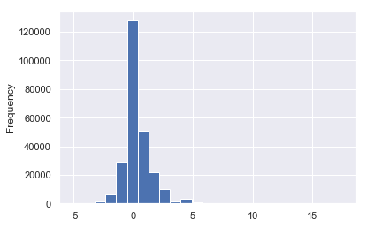

```python
plt.figure()
tablaNueva['coef'].plot.hist(bins=25)
```

```python
import matplotlib.pyplot as plt
import numpy as np
import pandas as pd
import seaborn as sns
import timeit
```

Luego se quiso ver como era la distribución del coeficiente según universidad, para así enfocarnos en un grupo específico y evaluar el porque de la demora.

```python
columns=['tipo_inst_2','coef','dur_total_anos']
reducido=pd.DataFrame(tablaNueva, columns=columns)
```

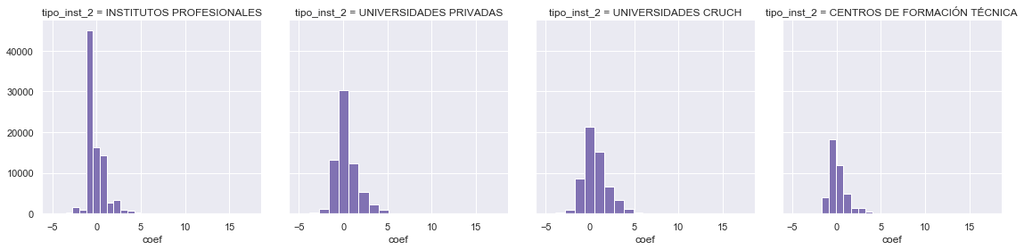

```python
import matplotlib.pyplot as plt
bins = np.arange(0, 65, 5)
g = sns.FacetGrid(reducido,col='tipo_inst_2',margin_titles=True,height=4,col_order=["INSTITUTOS PROFESIONALES", "UNIVERSIDADES PRIVADAS","UNIVERSIDADES CRUCH","CENTROS DE FORMACIÓN TÉCNICA"])
g = g.map(plt.hist, "coef",bins=20 ,color="m")
g.savefig("graficoMineria.png")
```

En la visualización anterior se puede apreciar que en los institutos profesionales y centros de formación técnica la gente sale en el tiempo debido, por lo que nuestro estudio se hará en las universidades privadas y las universidades del cruch

Ahora dado que daban resultados "extraños" en el coeficiente como -4, decidimos filtrar las filas tal que el coeficiente sea mayor que -2

```python
reducido=reducido.loc[reducido['coef']>-2]
```

```python
nuevo=reducido.groupby(['tipo_inst_2']).mean()
```

Luego se tiene otra visualizacion de donde se encuentra el coeficiente promedio mas alto y el promedio de duración total de la carrera promedio más alto según tipo de institución:

```python
cm = sns.light_palette("red", as_cmap=True)

s = nuevo.style.background_gradient(cmap=cm)
s
```

| tipo_inst_2 | coef | dur_total_anos |
| --- | --- | --- |
| CENTROS DE FORMACIÓN TÉCNICA | 0.113215 | 2.42632 |
| INSTITUTOS PROFESIONALES | 0.031279 | 2.99919 |
| UNIVERSIDADES CRUCH | 0.611375 | 4.6543 |
| UNIVERSIDADES PRIVADAS | 0.34298 | 4.54061 |

El resultado fue que las universidades del cruch tienen en promedio mayor coeficiente y además sus carreras duran más

# Experimentos : Clasificador

```python
tablaNueva=tablaNueva.loc[tablaNueva['coef']>=-1]
```

```python
mydictionare = {
    -0.5:'A',
    0.5:'B',
    -1:'A',
    0:'A',
    1:'B',
    2.5:'B',
    1.5:'B',
    2:'B',
    3.5:'B',
    4.5:'B',
    7:'B',
    3:'B',
    4:'B',
    5:'B',
    5.5:'B',
    6.5:'B',
    6:'B',
    7.5:'B',
    8:'B',
    8.5:'B',
    12:'B',
    8.5:'B',
    12:'B',
    11.5:'B',
    9.5:'B',
    15:'B',
    9:'B',
    14.5:'B',
    10:'B',
    17.5:'B',
    13:'B',
    16:'B',
    11:'B',
    12.5:'B',
    14:'B',
    17:'B'
}
```

```python
ans=[]
for key,value in mydictionare.items():
        ans.append([key,value])
clase=pd.DataFrame(ans, columns=['coef','clase'])
```

```python
tablaNuevaClases=pd.merge(tablaNueva,clase,on=['coef'],how='inner')
```

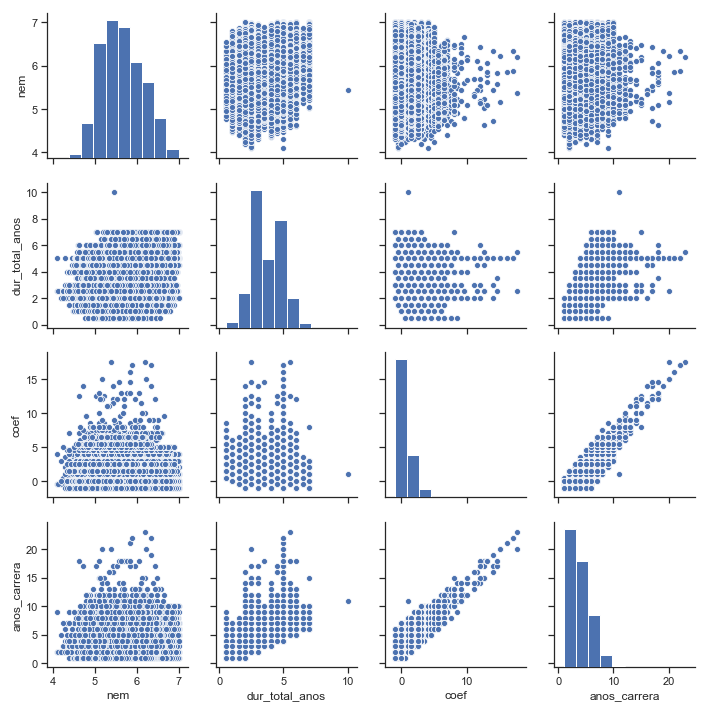

```python
reduced_data = tablaNuevaClases
import seaborn as sns
sns.set(style="ticks", color_codes=True)

g = sns.pairplot(reduced_data, vars=['nem', 'dur_total_anos', 'coef', 'anos_carrera'])
plt.show()
```

Para poder aplicar las técnicas de clasificación, se generó una tabla reducida donde se eliminaron las variables que se consideraba que tenían menos correlación con las clases. Así, sólo quedaron el género del alumno y la duración total de años de la carrera. De esta tabla se creó una muestra de 80000 filas debido a la demora al procesar los datos. Finalmente se mapearon las clases a tipos numéricos.

```python
tablaUniversidades=tablaNuevaClases.loc[(tablaNuevaClases['tipo_inst_2']=='UNIVERSIDADES PRIVADAS') | (tablaNuevaClases['tipo_inst_2']=='UNIVERSIDADES CRUCH')]
columns=['gen_alu', 'dur_total_anos','clase']
tablaUniversidades[['gen_alu']] = tablaUniversidades[['gen_alu']].astype(int)
tablaUniversidades=pd.DataFrame(tablaUniversidades,columns=columns)
tablaPrueba=tablaUniversidades.sample(n=80000)
tablaPrueba['clase'] = tablaPrueba['clase'].map({'A':1, 'B':3})
tablaPrueba = tablaPrueba.dropna()
array = tablaPrueba.values
```

Finalmente aquí se comienza a aplicar clasificación, partiendo con Árbol de Decisión. Los datos de entrenamiento corresponden al 70% de la muestra. Además, se evaluó el desempeño mediante la tabla de métricas y se contaron la cantidad de clases (a pesar de ser una selección aleatoria de la muestra siempre daba una proporción similar)

# Árbol de Decisión

```python
import numpy as np
from sklearn.model_selection import train_test_split
from sklearn.metrics import f1_score, recall_score, precision_score
from sklearn.tree import DecisionTreeClassifier
X = array[:,0:2]
y= array[:,2]
X_train, X_test, y_train, y_test = train_test_split(X, y, test_size=.30,train_size=0.70, stratify=y)
clf = DecisionTreeClassifier()
clf.fit(X_train, y_train)
predictions=clf.predict(X_test)

from sklearn.metrics import accuracy_score, classification_report
print(classification_report(y_test,predictions))
accuracy_score(y_test, predictions)

tablaUniversidades['clase'].value_counts()
```

```
             precision    recall  f1-score   support

        1.0       0.62      0.80      0.70     13666
        3.0       0.57      0.34      0.42     10334

avg / total       0.59      0.60      0.58     24000
```

```
A    68494
B    51902
Name: clase, dtype: int64
```

Con su respectiva matriz de confución

```
Text(0.5,0,'Predicted label')
```

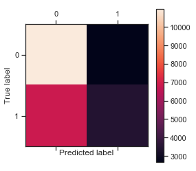

```python
from sklearn.metrics import confusion_matrix
cm = confusion_matrix(y_test, predictions)
plt.matshow(cm)
plt.colorbar()
plt.ylabel('True label')
plt.xlabel('Predicted label')
```

## k-fold

```python
from sklearn import metrics, model_selection

print("\nPREDICTIONS******")
predictions = model_selection.cross_val_predict(clf, X_test, y_test, cv=10)  ## cv es la cantidad de folds
print("Accuracy:", metrics.accuracy_score(y_test, predictions))
print("Metricas:")
print(metrics.classification_report(y_test, predictions))
```

```
PREDICTIONS******
Accuracy: 0.6024166666666667
Metricas:
             precision    recall  f1-score   support

        1.0       0.61      0.82      0.70     13666
        3.0       0.57      0.32      0.41     10334

avg / total       0.59      0.60      0.58     24000
```